# More dplyr and ggplot introduction

March 9th, 2016

## Before we start

Required packages and data:

- `dplyr`: obviously
- `ggplot2`: new package
- `storms.csv`: climate data for Central America (on MOLE)

**1. Load the `ggplot2` package**

```r
library("ggplot2")
```

This should already be installed. If you see errors, you may have to install it, e.g.

```r
install.packages("ggplot2")
```

Do the same for `dplyr` (you should NOT need to install it first)

**2. Read in the storms data**

Download the `storms.csv` data from MOLE. Set your working directory to the correct location and then use `read.csv` to read the data in (remember to use `stringsAsFactors = FALSE`), giving it the name `storms`.

## A bit more `dplyr`…

## Using `summarise`

### Calculating summaries of variables

## Basic usage

We use summarise to **calculate summary statistics** for further analysis. This is how to use `summarise`:

```r
summarise(data, SummaryVar = <expression>, ...)
```

**Arguments**

- `data`: a `data.frame` or `tbl` object
- `SummaryVar`: name of your summary variable
- `<expression>`: an R expression that references variables in `data` and returns to **a single value**

**Comments**

- The `<expression>` which appears on the right hand side of the `=` can be any valid R expression that uses variables in `data`. However, `<expression>` should return **a single value**.
- Although `summarise` looks a little like `mutate`, it is designed to construct a completely new dataset containing summaries of one or more variables.
- You may use more than one `SummaryStat = <expression>` at a time if you need to construct several summaries.

## Exercise

**Calculating the mean of two variables**

Use the `summarise` function with the `iris` dataset to calculate the mean sepal length and the mean sepal width.

Hint: You need to work out which R function calculates a mean. The clue is in the name.

```r
summarise(iris,
          mean_sl = mean(Sepal.Length),
          mean_sw = mean(Sepal.Width))
```

```
##    mean_sl  mean_sw
## 1 5.843333 3.057333
```

## Exercise

**Calculating a more complex summary of a variable**

Use the `summarise` function with the `iris` dataset to calculate the mean **area** of sepals.

```r
summarise(iris, mean_sl = mean(Sepal.Length * Sepal.Width))
```

```
##    mean_sl
## 1 17.82287
```

```r
summarise(iris, mean_sl = mean(Sepal.Length) * mean(Sepal.Width))
```

```
##    mean_sl
## 1 17.86502
```

Which one is right?

## Using `group_by`

### Making summaries for groups of observations

## Basic usage

We use `group_by` to add grouping information to a data frame or tibble. This is how we use `group_by`:

```r
group_by(data, GroupVar1, GroupVar2, ...)
```

**Arguments**

- `data`: a `data.frame` or `tbl` object
- `GroupVar`: name of grouping variable(s)

**Comments**

- The `group_by` does not do anything other than add grouping information to a `tbl`. It is only useful when used with `summarise` or `mutate`.
- Using `group_by` with `summarise` enables us to calculate numerical summaries on a *per group* basis.
- Using `group_by` with `mutate` enables us to add variables on a *per group* basis.

## Exercise

**Using `group_by` to calculate group-specific means**

Use the `group_by` function and the `summarise` functions with the `storms` dataset to calculate the mean wind speed associated with each storm **type**.

Hint: This is a two step exercise: 1) Use `group_by` to add some information to storms, remembering to assign the result a name; 2) These use `summarise` on this new dataset.

```r
# 1. make a grouped tibble
storms_grouped <- group_by(storms, type)
# 2. use summarise on the grouped data
summarise(storms_grouped, mean_wind = mean(wind))
```

```
## # A tibble: 4 × 2
##                  type mean_wind
##                 <chr>     <dbl>
## 1       Extratropical  40.06068
## 2           Hurricane  84.65960
## 3 Tropical Depression  27.35867
## 4      Tropical Storm  47.32181
```

## Exercise

**Using `group_by` to group by more than one variable**

Use the `group_by` and `summarise` functions with the `storms` dataset to calculate the mean and maximum wind speed associated with **each combination** of month and year. Assign the result a name and then use `View` to examine it. Which month in which year saw the largest maximum wind speed?

Hint: You can guess the names of the two functions that calculate the mean and max from a numeric vector.

```r
# 1. make a grouped tibble
storms_grouped <- group_by(storms, year, month)
# 2. use summarise on the grouped data
summarise(storms_grouped, mean_speed = mean(wind), max_speed = max(wind))
```

```
## Source: local data frame [30 x 4]
## Groups: year [?]
##
##     year month mean_speed max_speed
##    <int> <int>      <dbl>     <int>
## 1   1995     6   44.39394        65
## 2   1995     7   41.39241        60
## 3   1995     8   54.16000       120
## 4   1995     9   64.41489       120
## 5   1995    10   50.48485       130
## 6   1995    11   55.00000        70
## 7   1996     6   35.22727        45
## 8   1996     7   56.79104       100
## 9   1996     8   57.21374       125
## 10  1996     9   60.86806       120
## # ... with 20 more rows
```

## Exercise

**Using `group_by` and `mutate`**

The `group_by` function works with any **dplyr** verb that operates on variables (columns). Use the `group_by` and `mutate` functions with the `iris` dataset to calculate a "mean centred" version of sepal length. A centred variable is just one that has had its overall mean subtracted from every value.

Do you understand the different behaviour of `summarise` and `mutate` when used alongside `group_by`?

```r
# 1. group iris by species identity
iris_grouped <- group_by(iris, Species)
# 2. use mutate on the grouped data
mutate(iris_grouped, sl_centred = Sepal.Length - mean(Sepal.Length))
```

```
## Source: local data frame [150 x 6]
## Groups: Species [3]
##
##    Sepal.Length Sepal.Width Petal.Length Petal.Width Species sl_centred
##           <dbl>       <dbl>        <dbl>       <dbl>  <fctr>      <dbl>
## 1           5.1         3.5          1.4         0.2  setosa      0.094
## 2           4.9         3.0          1.4         0.2  setosa     -0.106
## 3           4.7         3.2          1.3         0.2  setosa     -0.306
## 4           4.6         3.1          1.5         0.2  setosa     -0.406
## 5           5.0         3.6          1.4         0.2  setosa     -0.006
## 6           5.4         3.9          1.7         0.4  setosa      0.394
## 7           4.6         3.4          1.4         0.3  setosa     -0.406
## 8           5.0         3.4          1.5         0.2  setosa     -0.006
## 9           4.4         2.9          1.4         0.2  setosa     -0.606
## 10          4.9         3.1          1.5         0.1  setosa     -0.106
## # ... with 140 more rows
```

## Using `%>%`

### piping or chaining

## Motivating example

We often need to perform a sequence of calculations on a vector or data frame. We do this by applying a series of function in sequence. Here are two ways to do this:

**1. Method 1: Store intermediate results…**

```r
x <- 10
x <- sqrt(x)
x <- exp(x)
round(x, 2)
```

```
## [1] 23.62
```

**1. Method 2: Use function nesting…**

```r
round(exp(sqrt(10)), 2)
```

```
## [1] 23.62
```

These do the same thing. Method 1 is easy to read, but is very verbose. Method 2 is concise, but not at all easy to read.

## A third way, using `%>%`…

The `dplyr` package includes a special operator, called "the pipe". It looks like this: `%>%`. This allows us to avoid strong intermediate results (method 1), while reading a sequence of function calls from left to right. For example:

```r
10 %>% sqrt(.) %>% exp(.) %>% round(., 2)
```

```
## [1] 23.62
```

Or equivalently, and even simpler…

```r
10 %>% sqrt() %>% exp() %>% round(2)
```

```
## [1] 23.62
```

## Why is this handy?

We can use `%>%` with any function we like. Look at this example of a two-step `group_by` and `summarise` operation with `iris`…

```r
# method 1
iris.grouped <- group_by(iris, Species)
summarise(iris.grouped, mean.SL = mean(Sepal.Length))

# method 2
summarise(group_by(iris, Species), mean.SL = mean(Sepal.Length))
```

The "piped" equivalent is more natural to read…

```r
iris %>%
  group_by(Species) %>%
  summarise(mean.SL = mean(Sepal.Length))
```

```
## # A tibble: 3 × 2
##      Species mean.SL
##       <fctr>   <dbl>
## 1     setosa   5.006
## 2 versicolor   5.936
## 3  virginica   6.588
```

## Exercise

**Using `group_by` to group by more than one variable**

Let's repeat the earlier `group_by` and `summarise` exercise, using the pipe. Rememeber, we used the `group_by` and `summarise` functions with the `storms` dataset to calculate the mean and maximum wind speed (in the `wind` variable) associated with each combination of month and year.

```r
storms %>%
  group_by(year, month) %>%
  summarise(mean_speed = mean(wind), max_speed = max(wind))
```

```
## Source: local data frame [30 x 4]
## Groups: year [?]
##
##     year month mean_speed max_speed
##    <int> <int>      <dbl>     <int>
## 1   1995     6   44.39394        65
## 2   1995     7   41.39241        60
## 3   1995     8   54.16000       120
## 4   1995     9   64.41489       120
## 5   1995    10   50.48485       130
## 6   1995    11   55.00000        70
## 7   1996     6   35.22727        45
## 8   1996     7   56.79104       100
## 9   1996     8   57.21374       125
## 10  1996     9   60.86806       120
## # ... with 20 more rows
```

## Moving on to `ggplot2`…

## Overview of `ggplot2`

### The grammar of graphics

## Why use `ggplot2`?

Roughly speaking, there are three commonly used plotting frameworks in R.

- base graphics: available as soon as you open R
- `lattice` package: create **trellis** graphs
- `ggplot2` implements a **grammar of graphics**.

**Advantages** of using `ggplot2`

- Consistent and intuitive framework for plotting
- Fleixble enough to make every plot you will need
- Works well with `dplyr`

**Disadvantages** of using `ggplot2`

- You have to learn "the grammar" to use it well
- Vast package, can be intimidating
- More than one way to do things

## Key concepts

You need to wrap your head around a few ideas to start using `ggplot2` effectively:

- **layers**: We build ggplot2 objects by adding one or more layers together. We can do this in a stepwise way, only plotting the object when we are ready. Each layer needs things like data, aesthetics, geometric objects, etc
- **aesthetics**: The word aesthetics refers to **the information** in a plot. For example, which variables are associated with the x and y axes? We specify this using the `aes` function.
- **geometric objects**: Geometric objects ("geoms") determine how the information is displayed. For example, will it be a scatter plot or a bar plot? We can specify geoms by adding a layer via functions beginning with `geom_`.

In practise, we build up a plot by combining different functions using the `+` operator. This has nothing to do with numeric addition!

## Illustrative example

Set up the basic object–define a default data frame and aesthetic…

```r
ggplot_object <- ggplot(my_df, aes(x = var1, y = var2))
```

Add a layer using the point 'geom'…

```r
ggplot_object <- ggplot_object + geom_point()
```

Show the plot–just 'print' the object to the console

```r
ggplot_object
```

## Real example: scatter plots

Scatter plots are used to show the relationship between 2 continuous variables. Using the `iris` dataset, let's examine the relationship between petal length and petal width.

**STEP 1**:

We use the `aes` function inside the `ggplot` function to specify which variables we plan to display. We also have to specify where the data are:

```r
plt <- ggplot(iris, aes(x = Petal.Width, y = Petal.Length))
```

All we did here was make a `ggplot` object. We can try to make the plot using the `print` function:

```r
print(plt)
```

This produces an empty plot because we haven't added a layer using a `geom_` function yet.

## Real example: scatter plots

**STEP 2**:

We want to make a scatter plot so we need to use the `geom_point` function:

```r
plt <- plt + geom_point()
```

Notice that all we do is "add" the required layer. Now we have something to plot:

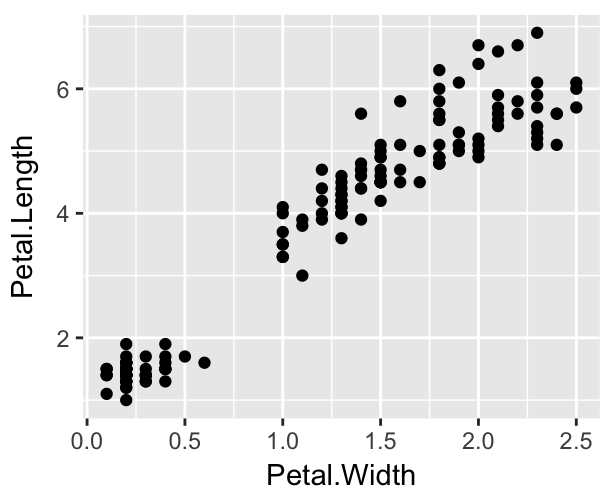

```r
print(plt)
```

## Real example: scatter plots

**STEP 3**:

Maybe we should improve the axis labels? To do this, we need to "add" labels information using the `labs` function

```r
plt <- plt + labs(x = "Petal Width", y = "Petal Length")
print(plt)
```

This just adds some new information about labelling to the prexisting `ggplot` object. Now it prints with improved axis labels:

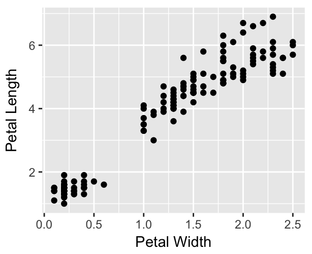

## Example: Scatter plots

**Doing it all in one go…**:

We don't have to build a plot object up in separate steps and then explicitly "print"" it to the Console. If we just want to make the plot in one go we can do it like this:

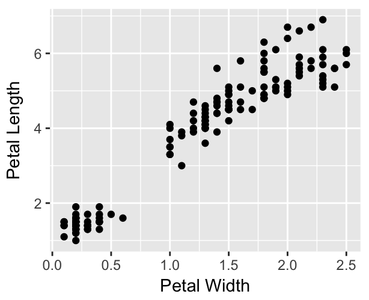

```r
ggplot(iris, aes(x = Petal.Width, y = Petal.Length)) +
  geom_point() +
  labs(x = "Petal Width", y = "Petal Length")
```

## Exercise

**Customising your plot**

Repeat the example we just stepped through, but now try to customise the point colours and their size. If that's too easy, see if you can make the points transparent. An example of suitable output is given below.

Hint: The `geom_point` function is responsible for altering these features (it takes a number of different arguments). It has arguments that control things like colour and size. They have sensible names…

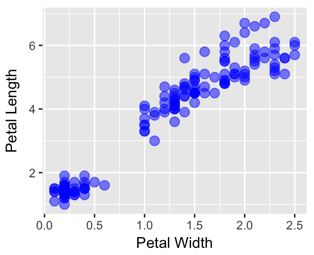

## Answer

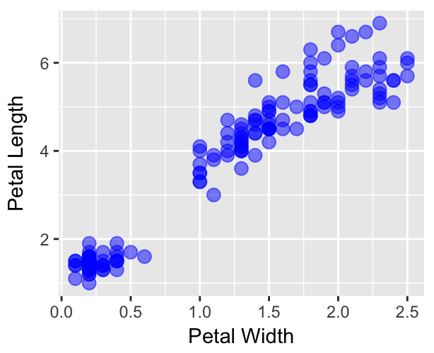

```r
ggplot(iris, aes(x = Petal.Width, y = Petal.Length)) +
  geom_point(colour = "blue", size = 3, alpha = 0.5) +
  labs(x = "Petal Width", y = "Petal Length")
```

## Adding more information

Q: The last graph was quite nice, but what information was missing?

A: The species identity!

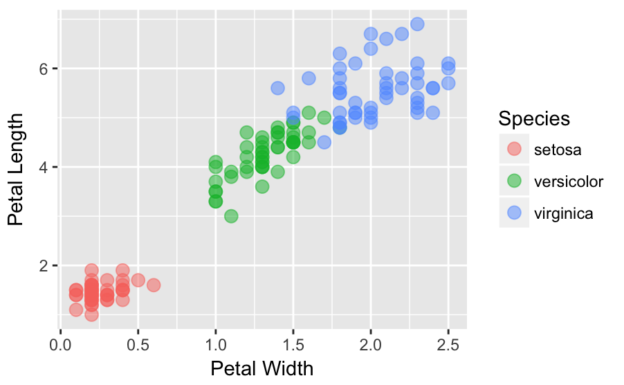

```r
ggplot(iris, aes(x = Petal.Width, y = Petal.Length, colour = Species)) +
  geom_point(size = 3, alpha = 0.5) +
  labs(x = "Petal Width", y = "Petal Length")
```

## Exercise

**Aesthetic mappings vs. arguments to `geom_`**

You may have noticed that we can set something like "colour" in two places: the aesthetic mapping (`aes`) or via an argument to a geom (`geom_`). What happens if we set the colour in both places at once? Experiment with the iris petal length vs. petal width scatter plot example to work this out. Which one—the aesthetic mapping geom argument—has precedence?

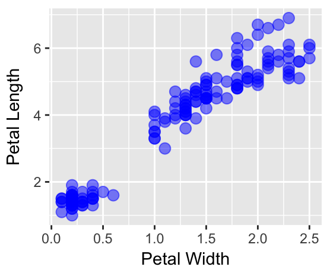

```r
ggplot(iris, aes(x = Petal.Width, y = Petal.Length, colour = Species)) +
  geom_point(colour = "blue", size = 3, alpha = 0.5) +
  labs(x = "Petal Width", y = "Petal Length")
```

## Exercise

**Using `dplyr` and `ggplot2` together (part 1)**

The first step is to work out how to use `dplyr` to calcuate the mean `wind` speed and mean `pressure` for each combination of storm `name` and `type`. Do this with the pipe (`%>%`) operator, and give the resulting data the name `storms.summary`.

```r
storms.summary <-
  storms %>%
  group_by(name, type) %>%
  summarise(wind = mean(wind), pressure = mean(pressure))
```

## Exercise

**Using `dplyr` and `ggplot2` together (part 2)**

The next step uses the `storms.summary` data to plot the mean `wind` speed and mean `pressure` for each name-type case. Remember to colour the points by `type`.

```r
ggplot(storms.summary,
       aes(x = pressure, y = wind, col = type)) +
  geom_point(alpha = 0.7) +
  labs(x = "Mean pressure (mbar)", y = "Mean wind speed (mph)")
```

[output not shown]

## Exercise

**Using `dplyr` and `ggplot2` together (part 3)**

Finally, see if you can combine the solutions to part 1 and 2 into a single "piped" operation. That is, instead of storing the intermediate data in `storms.summary`, use the pipe (`%>%`) to send the data straight to `ggplot`.

```r
storms %>%
  group_by(name, type) %>%
  summarise(wind = mean(wind), pressure = mean(pressure)) %>%
  ggplot(aes(x = pressure, y = wind, col = type)) +
    geom_point(alpha = 0.7) +
    labs(x = "Mean pressure (mbar)", y = "Mean wind speed (mph)")
```

## What happens next?

1. **No lecture** tomorrow.
2. Course book, course book, course book! (No one reported my 'deliberate' error…)
3. DZC office hours are 12-3pm every Tuesday. (No one has been to see me…)
4. More plotting next week (Then we're done…)